# Model_Retraining_Project_GL

```python
# import necessary libraries
import pandas as pd
import numpy as np

import matplotlib.pyplot as plt
%matplotlib inline
import seaborn as sns

import warnings
warnings.filterwarnings('ignore')

from pyecharts.charts import Bar, WordCloud
from pyecharts import options as opts
from sklearn.preprocessing import StandardScaler
```

```python
# load my dataset
df = pd.read_csv('Downloads/Myntra Fasion Clothing.csv')
```

```python
# first 5 rows of dataset
df.head()
```

|  | URL | Product_id | BrandName | Category | Individual_category | category_by_Gender | Description | DiscountPrice (in Rs) | OriginalPrice (in Rs) | DiscountOffer | SizeOption | Ratings | Reviews |
| --- | --- | --- | --- | --- | --- | --- | --- | --- | --- | --- | --- | --- | --- |
| 0 | https://www.myntra.com/jeans/roadster/roadster... | 2296012 | Roadster | Bottom Wear | jeans | Men | roadster men navy blue slim fit mid rise clean... | 824.0 | 1499.0 | 45% OFF | 28, 30, 32, 34, 36 | 3.9 | 999.0 |
| 1 | https://www.myntra.com/track-pants/locomotive/... | 13780156 | LOCOMOTIVE | Bottom Wear | track-pants | Men | locomotive men black white solid slim fit tra... | 517.0 | 1149.0 | 55% OFF | S, M, L, XL | 4.0 | 999.0 |
| 2 | https://www.myntra.com/shirts/roadster/roadste... | 11895958 | Roadster | Topwear | shirts | Men | roadster men navy white black geometric print... | 629.0 | 1399.0 | 55% OFF | 38, 40, 42, 44, 46, 48 | 4.3 | 999.0 |
| 3 | https://www.myntra.com/shapewear/zivame/zivame... | 4335679 | Zivame | Lingerie & Sleep Wear | shapewear | Women | zivame women black saree shapewear zi3023core0... | 893.0 | 1295.0 | 31% OFF | S, M, L, XL, XXL | 4.2 | 999.0 |
| 4 | https://www.myntra.com/tshirts/roadster/roadst... | 11690882 | Roadster | Western | tshirts | Women | roadster women white solid v neck pure cotton ... | NaN | 599.0 | 35% OFF | XS, S, M, L, XL | 4.2 | 999.0 |

```python
# columns in dataset
df.columns
```

```
Index(['URL', 'Product_id', 'BrandName', 'Category', 'Individual_category',
       'category_by_Gender', 'Description', 'DiscountPrice (in Rs)',
       'OriginalPrice (in Rs)', 'DiscountOffer', 'SizeOption', 'Ratings',
       'Reviews'],
      dtype='object')
```

```python
df.shape
```

```
(526564, 13)
```

This dataset contains 526564 clothes records, and has 13 columns. The columns are: website address, the id of the product, the name of the brand, small category, large category, for which gender, description, the price after discounting, the original price, the discount rate, all sizes can be chosen, ratings, how many reviews

```python
df.describe()
```

|  | Product_id | DiscountPrice (in Rs) | OriginalPrice (in Rs) | Ratings | Reviews |
| --- | --- | --- | --- | --- | --- |
| count | 5.265640e+05 | 333406.000000 | 526564.000000 | 190412.000000 | 190412.000000 |
| mean | 1.506939e+07 | 1237.444401 | 2414.068615 | 4.094892 | 61.990820 |
| std | 3.225710e+06 | 1052.063517 | 1916.962914 | 0.494158 | 125.714537 |
| min | 2.739900e+04 | 127.000000 | 99.000000 | 1.000000 | 0.000000 |
| 25% | 1.388053e+07 | 659.000000 | 1299.000000 | 3.900000 | 8.000000 |
| 50% | 1.597106e+07 | 952.000000 | 1999.000000 | 4.200000 | 18.000000 |
| 75% | 1.734741e+07 | 1469.000000 | 2899.000000 | 4.400000 | 52.000000 |
| max | 1.846435e+07 | 27996.000000 | 90000.000000 | 5.000000 | 999.000000 |

Most discount price are less than 1469 and most original price are less than 2899. Most rates are higher than 3.9, while most products have less than 52 reviews. So, many products are relatively cheap with less discounts. The rates are relatively high but not many products are so attractive that customers want to give it a comment.

```python
df.info()
```

```
<class 'pandas.core.frame.DataFrame'>
RangeIndex: 526564 entries, 0 to 526563
Data columns (total 13 columns):
URL                      526564 non-null object
Product_id               526564 non-null int64
BrandName                526564 non-null object
Category                 526564 non-null object
Individual_category      526564 non-null object
category_by_Gender       526564 non-null object
Description              526564 non-null object
DiscountPrice (in Rs)    333406 non-null float64
OriginalPrice (in Rs)    526564 non-null float64
DiscountOffer            452258 non-null object
SizeOption               526564 non-null object
Ratings                  190412 non-null float64
Reviews                  190412 non-null float64
dtypes: float64(4), int64(1), object(8)
memory usage: 52.2+ MB
```

# Data Preprocessing

```python
# change column name
df.rename(columns={"Individual_category" : "IndividualCategory", "Product_id" : "ProductId",
                       "category_by_Gender" : "Gender", "DiscountPrice (in Rs)" : "DiscountPrice",
                       "OriginalPrice (in Rs)" : "OriginalPrice"},inplace = True)
```

```python
# category_by_gender. I change the gender to (0,1) variables,1 for male and 0 for female.
df.loc[df["Gender"] == "Men","Gender"] = 1
df.loc[df["Gender"] == "Women","Gender"] = 0
```

```python
# check the gender
df["Gender"]
```

```
0         1
1         1
2         1
3         0
4         0
5         0
6         1
7         0
8         0
9         1
10        1
11        1
12        0
13        0
14        0
```

[output cut: 47 more lines]

```python
# check discount offer column
df['DiscountOffer']
```

```
0                 45% OFF
1                 55% OFF
2                 55% OFF
3                 31% OFF
4                 35% OFF
5                 40% OFF
6                 60% OFF
7                 58% OFF
8                     NaN
9                     NaN
10                55% OFF
11                    NaN
12                70% OFF
13                50% OFF
14                60% OFF
```

[output cut: 47 more lines]

```python
# DiscountOffer. First fill empty values with "0". Since there are "...% OFF", "... OFF" AND "0" in this
# column, I change "... OFF" to "... % OFF", change "... % OFF" to float and change others to 0.
# Then calculate the price after discount by OriginalPrice*(1-DiscountOffer)

df["DiscountOffer"].fillna("0",inplace=True)

def disRs_sep(discount):
    s = discount.split(" ")[1]
    return float(s)

def disper_sep(discount):
    s = discount.split("%")[0]
    return float(s)

d1 = df[df["DiscountOffer"].str.contains("%")]
d2 = df[df["DiscountOffer"].str.contains("Rs.")]
d3 = df[df["DiscountOffer"] == "0"]

d1["DiscountOffer"] = round(d1["DiscountOffer"].apply(disper_sep)/100,2)
d2["DiscountOffer"] = d2["DiscountOffer"].apply(disRs_sep)
d2["DiscountOffer"] = round(d2["DiscountOffer"] / d2["OriginalPrice"],2)
d3["DiscountOffer"] = round(0,2)
```

```python
# concat them together
df1 = pd.concat([d1,d2,d3])
df1.sort_index(inplace = True)
```

```python
# DiscountPrice
d4 = df1[df1["DiscountPrice"].isnull()]
d5 = df1[df1["DiscountPrice"].notnull()]
d4["DiscountPrice"] = round(d4["OriginalPrice"] * (1 - d4["DiscountOffer"]),0)
df2 = pd.concat([d4,d5])
df2.sort_index(inplace = True)
```

```python
df2.head()
```

|  | URL | ProductId | BrandName | Category | IndividualCategory | Gender | Description | DiscountPrice | OriginalPrice | DiscountOffer | SizeOption | Ratings | Reviews |
| --- | --- | --- | --- | --- | --- | --- | --- | --- | --- | --- | --- | --- | --- |
| 0 | https://www.myntra.com/jeans/roadster/roadster... | 2296012 | Roadster | Bottom Wear | jeans | 1 | roadster men navy blue slim fit mid rise clean... | 824.0 | 1499.0 | 0.45 | 28, 30, 32, 34, 36 | 3.9 | 999.0 |
| 1 | https://www.myntra.com/track-pants/locomotive/... | 13780156 | LOCOMOTIVE | Bottom Wear | track-pants | 1 | locomotive men black white solid slim fit tra... | 517.0 | 1149.0 | 0.55 | S, M, L, XL | 4.0 | 999.0 |
| 2 | https://www.myntra.com/shirts/roadster/roadste... | 11895958 | Roadster | Topwear | shirts | 1 | roadster men navy white black geometric print... | 629.0 | 1399.0 | 0.55 | 38, 40, 42, 44, 46, 48 | 4.3 | 999.0 |
| 3 | https://www.myntra.com/shapewear/zivame/zivame... | 4335679 | Zivame | Lingerie & Sleep Wear | shapewear | 0 | zivame women black saree shapewear zi3023core0... | 893.0 | 1295.0 | 0.31 | S, M, L, XL, XXL | 4.2 | 999.0 |
| 4 | https://www.myntra.com/tshirts/roadster/roadst... | 11690882 | Roadster | Western | tshirts | 0 | roadster women white solid v neck pure cotton ... | 389.0 | 599.0 | 0.35 | XS, S, M, L, XL | 4.2 | 999.0 |

```python
df2.Ratings.unique()
```

```
array([3.9, 4. , 4.3, 4.2, 4.4, 3.7, 3.5, 4.1, 3.8, 3.6, 4.5, 4.6, 3.4,
       3.2, 4.7, 3.3, 3. , 3.1, 2.9, 2.8, 2.6, 2.5, 2.4, 2. , 2.7, 4.8,
       4.9, 2.3, 1.6, 2.2, 2.1, 1.8, 5. , 1.2, 1.9, 1.7, 1.4, 1.5, 1.1,
       1. , 1.3, nan])
```

```python
df2.columns
```

```
Index(['URL', 'ProductId', 'BrandName', 'Category', 'IndividualCategory',
       'Gender', 'Description', 'DiscountPrice', 'OriginalPrice',
       'DiscountOffer', 'SizeOption', 'Ratings', 'Reviews'],
      dtype='object')
```

```python
# Reviews and Ratings
df2["Reviews"].fillna(0,inplace = True)
#df2["Ratings"].fillna(0,inplace = True)
df2["Reviews"] = df2["Reviews"].astype(int)
```

```python
# drop the URL (it can be gotten by merge the final dataset with clothes dataset or use clothes 2 dataset directly)
# and the description (which can be used to get a item picture or a word cloud, it will be done later)
df3 = df2.drop(["URL","Description"],axis = 1)
```

```python
# check variant values
df3["Gender"].unique()
```

```
array([1, 0], dtype=int64)
```

```python
# check duplicated values
df3.duplicated().sum()
```

```
0
```

```python
# check empty values
df3.info()
```

```
<class 'pandas.core.frame.DataFrame'>
Int64Index: 526564 entries, 0 to 526563
Data columns (total 11 columns):
ProductId             526564 non-null int64
BrandName             526564 non-null object
Category              526564 non-null object
IndividualCategory    526564 non-null object
Gender                526564 non-null int64
DiscountPrice         526564 non-null float64
OriginalPrice         526564 non-null float64
DiscountOffer         526564 non-null float64
SizeOption            526564 non-null object
Ratings               190412 non-null float64
Reviews               526564 non-null int32
dtypes: float64(4), int32(1), int64(2), object(4)
memory usage: 46.2+ MB
```

```python
# clean dataset
df3.head()
```

|  | ProductId | BrandName | Category | IndividualCategory | Gender | DiscountPrice | OriginalPrice | DiscountOffer | SizeOption | Ratings | Reviews |
| --- | --- | --- | --- | --- | --- | --- | --- | --- | --- | --- | --- |
| 0 | 2296012 | Roadster | Bottom Wear | jeans | 1 | 824.0 | 1499.0 | 0.45 | 28, 30, 32, 34, 36 | 3.9 | 999 |
| 1 | 13780156 | LOCOMOTIVE | Bottom Wear | track-pants | 1 | 517.0 | 1149.0 | 0.55 | S, M, L, XL | 4.0 | 999 |
| 2 | 11895958 | Roadster | Topwear | shirts | 1 | 629.0 | 1399.0 | 0.55 | 38, 40, 42, 44, 46, 48 | 4.3 | 999 |
| 3 | 4335679 | Zivame | Lingerie & Sleep Wear | shapewear | 0 | 893.0 | 1295.0 | 0.31 | S, M, L, XL, XXL | 4.2 | 999 |
| 4 | 11690882 | Roadster | Western | tshirts | 0 | 389.0 | 599.0 | 0.35 | XS, S, M, L, XL | 4.2 | 999 |

# EDA

Which brand had most products on myntra?

```python
# how many brands
df3["BrandName"].nunique()
```

```
2088
```

```python
# TOP 10 brands sold most products
brandt10 = df3["ProductId"].groupby(df3["BrandName"]).count().sort_values(ascending = False).head(10)
x = brandt10.index.tolist()[::-1]
y = brandt10.values.tolist()[::-1]
bar = (
    Bar(init_opts = opts.InitOpts(theme = "chalk"))
    .add_xaxis(xaxis_data = x)
    .add_yaxis(series_name = "", y_axis = y)
    .set_global_opts(title_opts = opts.TitleOpts(title = "The brand had most products TOP 10",
                                                 pos_left = "center"),
                    visualmap_opts = opts.VisualMapOpts(type_ = "color",
                                                        pos_bottom = "center", pos_right = "10%",
                                                        min_ = 0, max_ = 10),
                    xaxis_opts = opts.AxisOpts(name = "products"),
                    yaxis_opts = opts.AxisOpts(name = "brands"))
    .set_series_opts(label_opts = opts.LabelOpts(is_show = True, position = "right"))
    .reversal_axis()
)
bar.render_notebook()
```

Pothys, Roadster and KALINI are the top3 brands who had most products on myntra. Pothys had more than 16K products, which was much more than other brands.

what kinds of clothes were the most on myntra?

```python
Category_top10 = df3["ProductId"].groupby(df3["Category"]).count().sort_values(ascending = False).head(10)
IndividualCategory_top10 = df3["ProductId"].groupby(df3["IndividualCategory"]).count().sort_values(ascending = False).head(10)
SmallCategory_top10 = df3["ProductId"].groupby([df3["IndividualCategory"],df3["Category"]]).count().sort_values(ascending = False).head(10)
```

```python
# TOP 10 categories had most products
x = Category_top10.index.tolist()[::-1]
y = Category_top10.values.tolist()[::-1]
bar2 = (
    Bar(init_opts = opts.InitOpts(theme = "chalk"))
    .add_xaxis(xaxis_data = x)
    .add_yaxis(series_name = "", y_axis = y)
    .set_global_opts(title_opts = opts.TitleOpts(title = "The category had most products TOP 10",
                                                 pos_left = "center"),
                    visualmap_opts = opts.VisualMapOpts(type_ = "color",
                                                        pos_bottom = "center", pos_right = "10%",
                                                        min_ = 0, max_ = 10),
                    xaxis_opts = opts.AxisOpts(name = "products"),
                    yaxis_opts = opts.AxisOpts(name = "category"))
    .set_series_opts(label_opts = opts.LabelOpts(is_show = True, position = "right"))
    .reversal_axis()
)
bar2.render_notebook()
```

There were more than 140K Indian wear and Western clothes on myntra, while only 13K plus size clothes were sold on myntra.

```python
# TOP 10 individual categories had most products
x = IndividualCategory_top10.index.tolist()[::-1]
y = IndividualCategory_top10.values.tolist()[::-1]
bar3 = (
    Bar(init_opts = opts.InitOpts(theme = "chalk"))
    .add_xaxis(xaxis_data = x)
    .add_yaxis(series_name = "", y_axis = y)
    .set_global_opts(title_opts = opts.TitleOpts(title = "The individual category had most products TOP 10",
                                                 pos_left = "center"),
                    visualmap_opts = opts.VisualMapOpts(type_ = "color",
                                                        pos_bottom = "center", pos_right = "10%",
                                                        min_ = 0, max_ = 10),
                    xaxis_opts = opts.AxisOpts(name = "products"),
                    yaxis_opts = opts.AxisOpts(name = "individual category"))
    .set_series_opts(label_opts = opts.LabelOpts(is_show = True, position = "right"))
    .reversal_axis()
)
bar3.render_notebook()
```

Most clothes on myntra were t-shirts or sarees, about 61K and 58K respectively, which were much higher than that of others.

```python
# TOP 10 small categories had most products
x = SmallCategory_top10.index.tolist()[::-1]
y = SmallCategory_top10.values.tolist()[::-1]
bar4 = (
    Bar(init_opts = opts.InitOpts(theme = "chalk"))
    .add_xaxis(xaxis_data = x)
    .add_yaxis(series_name = "", y_axis = y)
    .set_global_opts(title_opts = opts.TitleOpts(title = "The small category had most products TOP 10",
                                                 pos_left = "center"),
                    visualmap_opts = opts.VisualMapOpts(type_ = "color",
                                                        pos_bottom = "center", pos_right = "10%",
                                                        min_ = 0, max_ = 10),
                    xaxis_opts = opts.AxisOpts(name = "products"),
                    yaxis_opts = opts.AxisOpts(name = "small category"))
    .set_series_opts(label_opts = opts.LabelOpts(is_show = True, position = "right"))
    .reversal_axis()
)
bar4.render_notebook()
```

The indian wear sarees had a dominant role on myntra, with about 57K products. And we can see that almost all the sarees are indian wear.

what kinds of clothes have the highest discount rate?

```python
Category_discountrate_top5 = df3["DiscountOffer"].groupby(df3["Category"]).mean().apply(lambda x:round(x,2)).sort_values(ascending = False).head(5)
IndividualCategory_discountrate_top5 = df3["DiscountOffer"].groupby(df3["IndividualCategory"]).mean().apply(lambda x:round(x,2)).sort_values(ascending = False).head(5)
SmallCategory_discountrate_top5 = df3["DiscountOffer"].groupby([df3["IndividualCategory"],df3["Category"]]).mean().apply(lambda x:round(x,2)).sort_values(ascending = False).head(5)
Brand_discountrate_top5 = df3["DiscountOffer"].groupby(df3["BrandName"]).mean().apply(lambda x:round(x,2)).sort_values(ascending = False).head(5)
```

```python
# TOP 5 categories had most discount rate
x = Category_discountrate_top5.index.tolist()[::-1]
y = Category_discountrate_top5.values.tolist()[::-1]
bar5 = (
    Bar(init_opts = opts.InitOpts(theme = "chalk"))
    .add_xaxis(xaxis_data = x)
    .add_yaxis(series_name = "", y_axis = y)
    .set_global_opts(title_opts = opts.TitleOpts(title = "The category had most discount rate",
                                                 pos_left = "center"),
                    visualmap_opts = opts.VisualMapOpts(type_ = "color",
                                                        pos_bottom = "center", pos_right = "10%",
                                                        min_ = 0, max_ = 10),
                    xaxis_opts = opts.AxisOpts(name = "discount rate"),
                    yaxis_opts = opts.AxisOpts(name = "category"))
    .set_series_opts(label_opts = opts.LabelOpts(is_show = True, position = "right"))
    .reversal_axis()
)
bar5.render_notebook()
```

```python
# TOP 5 brands had most discount rate
x = Brand_discountrate_top5.index.tolist()[::-1]
y = Brand_discountrate_top5.values.tolist()[::-1]
bar6 = (
    Bar(init_opts = opts.InitOpts(theme = "chalk"))
    .add_xaxis(xaxis_data = x)
    .add_yaxis(series_name = "", y_axis = y)
    .set_global_opts(title_opts = opts.TitleOpts(title = "The brand had most discount rate",
                                                 pos_left = "center"),
                    visualmap_opts = opts.VisualMapOpts(type_ = "color",
                                                        pos_bottom = "center", pos_right = "10%",
                                                        min_ = 0, max_ = 10),
                    xaxis_opts = opts.AxisOpts(name = "discount rate"),
                    yaxis_opts = opts.AxisOpts(name = "brand"))
    .set_series_opts(label_opts = opts.LabelOpts(is_show = True, position = "right"))
    .reversal_axis()
)
bar6.render_notebook()
```

As for discount rate, there is nothing special for small category or individual category, so only category and brand are shown here. Plus size clothes and Indian wear have high discount rate, which is near half of the price. This may because Indian wear is the most popular one and high discount rate can encourage the consumption, while plus size clothes are not so popular, so high discount rate can draw consumers'attention. TOP5 brands have a relatively high mean discount rate, which are all higher than 80%. Especially HRITIKA, which have a high mean discount rate at 89%.

Whose clothes are cheaper, and whose clothes have large discount rate, Men or Women?

```python
gender_discountrate = df3["DiscountOffer"].groupby(df3["Gender"]).mean().apply(lambda x: round(x,2))
gender_discountprice = df3["DiscountPrice"].groupby(df3["Gender"]).mean().apply(lambda x: round(x,2))
```

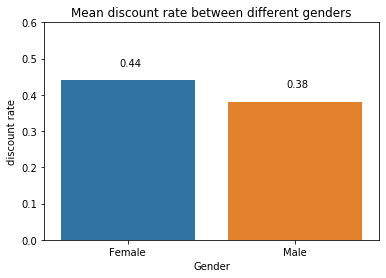

```python
# Mean discount rate between different genders
sns.barplot(gender_discountrate.index,gender_discountrate.values)
plt.title("Mean discount rate between different genders")
plt.ylabel("discount rate")
names = ["Female","Male"]
plt.xticks(ticks = np.arange(2), labels = names)
plt.ylim(0,0.6)
plt.text(-0.05,0.48,gender_discountrate.values[0])
plt.text(0.95,0.42,gender_discountrate.values[1])
plt.show()
```

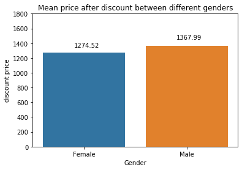

```python
# Mean price after discount between different genders
sns.barplot(gender_discountprice.index,gender_discountprice.values)
plt.title("Mean price after discount between different genders")
plt.ylabel("discount price")
names = ["Female","Male"]
plt.xticks(ticks = np.arange(2), labels = names)
plt.ylim(0,1800)
plt.text(-0.1,1350,gender_discountprice.values[0])
plt.text(0.9,1450,gender_discountprice.values[1])
plt.show()
```

From the bar plots above, we can see that average discount rate on female clothes was higher than that of male clothes and the average price after discount of female colthes was lower than that of male clothes.

Which brand offered more size choice? (average)

```python
df3["SizeNum"] = df3["SizeOption"]
def size_num(option):
    options = option.split(",")
    return len(options)
df3["SizeNum"] = df3["SizeNum"].apply(size_num)
```

```python
# The products provided most size options
ItemSize = df3[["ProductId","SizeNum"]].sort_values(by = ["SizeNum"],ascending = False).head(10).reset_index(drop = True)
ItemSize
```

|  | ProductId | SizeNum |
| --- | --- | --- |
| 0 | 10013611 | 80 |
| 1 | 13558954 | 56 |
| 2 | 13558934 | 56 |
| 3 | 8640805 | 55 |
| 4 | 16208720 | 55 |
| 5 | 16208742 | 55 |
| 6 | 16208722 | 55 |
| 7 | 8640847 | 55 |
| 8 | 8640857 | 55 |
| 9 | 16208740 | 55 |

```python
# The brands provided most size options
BrandSize = df3["SizeNum"].groupby(df3["BrandName"]).mean().apply(lambda x: round(x,0)).sort_values(ascending = False).head(10)
BrandSize
```

```
BrandName
Centra      35.0
PARFAIT     34.0
Souminie    21.0
Rajnie      18.0
laavian     17.0
next        15.0
Samshek     14.0
Bwitch      13.0
KOMLI       13.0
Susie       12.0
Name: SizeNum, dtype: float64
```

```python
# The product provided most size options
df3[df3["ProductId"] == 10013611]
```

|  | ProductId | BrandName | Category | IndividualCategory | Gender | DiscountPrice | OriginalPrice | DiscountOffer | SizeOption | Ratings | Reviews | SizeNum |
| --- | --- | --- | --- | --- | --- | --- | --- | --- | --- | --- | --- | --- |
| 36881 | 10013611 | PARFAIT | Lingerie & Sleep Wear | bra | 0 | 1839.0 | 2299.0 | 0.2 | 30D, 30DD, 30E, 30F, 30FF, 30G, 30GG, 30H, 30H... | 4.0 | 71 | 80 |

```python
size_option_value = df3.loc[df3['ProductId'] == 10013611, 'SizeOption'].iloc[0]
```

```python
size_option_value
```

```
'30D, 30DD, 30E, 30F, 30FF, 30G, 30GG, 30H, 30HH, 30J, 30JJ, 30K, 32D, 32DD, 32E, 32F, 32FF, 32G, 32GG, 32H, 32HH, 32J, 32JJ, 32K, 34D, 34DD, 34E, 34F, 34FF, 34G, 34GG, 34H, 34HH, 34J, 34JJ, 34K, 36D, 36DD, 36E, 36F, 36FF, 36G, 36GG, 36H, 36HH, 36J, 36JJ, 38D, 38DD, 38E, 38F, 38FF, 38G, 38GG, 38H, 3…
```

Many items have lots of size options available, some items offer more than 50 sizes. The product whose productid is 10013611 has most available size, about 80 size options. THe information of it is shown above. As for the brand, Central PARFAIT and Souminie are the top 3 brand, who offers most size options, the numbers are 35,34 and 21 respectively.

Which brand had most reviews?

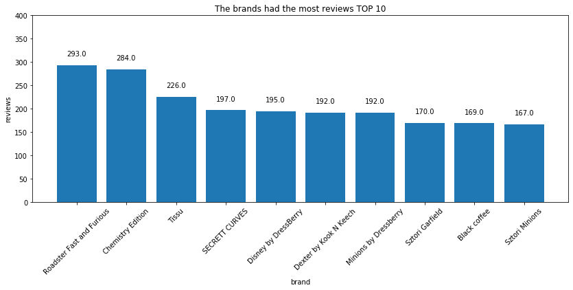

```python
# The brand had most reviews
BrandReviews = df3["Reviews"].groupby(df3["BrandName"]).mean().apply(lambda x: round(x,0)).sort_values(ascending = False).head(10)
plt.figure(figsize=(14,5))
plt.bar(BrandReviews.index,BrandReviews.values)
plt.xlabel("brand")
plt.ylabel("reviews")
plt.xticks(rotation = 45)
plt.ylim(0,400)
for i in range(0,len(BrandReviews.values)):
    plt.text(i - 0.2,BrandReviews.values[i] + 20,BrandReviews.values[i])
plt.title("The brands had the most reviews TOP 10")
plt.show()
```

Roadster Fast and Furious had the most reviews, at 293 reviews per item, while Chemistry Edition had the second place. Tissu is the third popular brand with 226 reviews per item. They all had more than 200 reviews per item. Then came SECRETT CURVES, Disney by DressBerry, Dexter by Kook N Keech and Minions by Dressberry, all had about 190 reviews per item.

Which brand had highest rating?

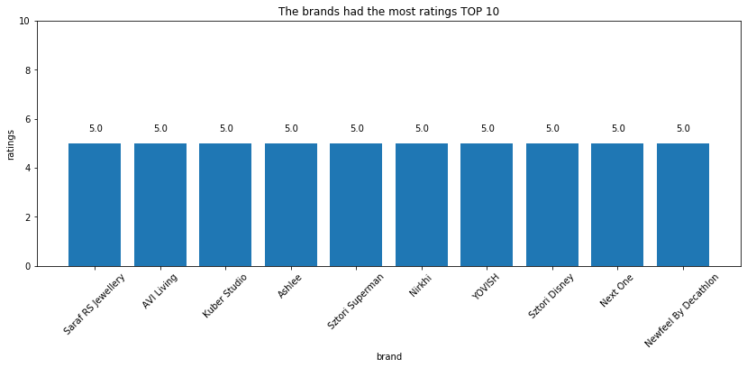

```python
# The brand had highest ratings
BrandRatings = df3["Ratings"].groupby(df3["BrandName"]).mean().apply(lambda x: round(x,0)).sort_values(ascending = False).head(10)
plt.figure(figsize=(14,5))
plt.bar(BrandRatings.index,BrandRatings.values)
plt.xlabel("brand")
plt.ylabel("ratings")
plt.xticks(rotation = 45)
plt.ylim(0,10)
for i in range(0,len(BrandRatings.values)):
    plt.text(i - 0.1,BrandRatings.values[i] + 0.5,BrandRatings.values[i])
plt.title("The brands had the most ratings TOP 10")
plt.show()
```

```python
# How many reviews for the highest-rating-brands
BrandReview = df3["Reviews"].groupby(df3["BrandName"]).mean().apply(lambda x: round(x,0)).reset_index()
rating5 = ["Sztori Superman","Minions by Dressberry","Zelocity","Newfeel By Decathlon",
                                        "Sztori Disney","Dennis Morton","Forca by Lifestyle"]
for i in rating5:
    print(BrandReview[BrandReview["BrandName"] == i])
    print("\n")
```

```
            BrandName  Reviews
1691  Sztori Superman      9.0


                  BrandName  Reviews
1123  Minions by Dressberry    192.0


     BrandName  Reviews
1964  Zelocity      8.0


                 BrandName  Reviews
1204  Newfeel By Decathlon     10.0


          BrandName  Reviews
1687  Sztori Disney     42.0


         BrandName  Reviews
447  Dennis Morton      5.0


              BrandName  Reviews
611  Forca by Lifestyle      9.0
```

```python
# how is the rating for the most-review-brands
BrandRating = df3["Ratings"].groupby(df3["BrandName"]).mean().apply(lambda x: round(x,0)).reset_index()
review10 = BrandReviews.index
for i in review10:
    print(BrandRating[BrandRating["BrandName"] == i])
    print("\n")
```

```
                      BrandName  Ratings
1454  Roadster Fast and Furious      4.0


             BrandName  Ratings
343  Chemistry Edition      4.0


     BrandName  Ratings
1759     Tissu      4.0


           BrandName  Ratings
1493  SECRETT CURVES      4.0


                BrandName  Ratings
454  Disney by DressBerry      4.0


                  BrandName  Ratings
451  Dexter by Kook N Keech      4.0


                  BrandName  Ratings
1123  Minions by Dressberry      5.0


            BrandName  Ratings
1688  Sztori Garfield      4.0


        BrandName  Ratings
246  Black coffee      4.0


           BrandName  Ratings
1690  Sztori Minions      4.0
```

# Feature Engineering

```python
df4 = df3.copy()
df4.head()
```

|  | ProductId | BrandName | Category | IndividualCategory | Gender | DiscountPrice | OriginalPrice | DiscountOffer | SizeOption | Ratings | Reviews | SizeNum |
| --- | --- | --- | --- | --- | --- | --- | --- | --- | --- | --- | --- | --- |
| 0 | 2296012 | Roadster | Bottom Wear | jeans | 1 | 824.0 | 1499.0 | 0.45 | 28, 30, 32, 34, 36 | 3.9 | 999 | 5 |
| 1 | 13780156 | LOCOMOTIVE | Bottom Wear | track-pants | 1 | 517.0 | 1149.0 | 0.55 | S, M, L, XL | 4.0 | 999 | 4 |
| 2 | 11895958 | Roadster | Topwear | shirts | 1 | 629.0 | 1399.0 | 0.55 | 38, 40, 42, 44, 46, 48 | 4.3 | 999 | 6 |
| 3 | 4335679 | Zivame | Lingerie & Sleep Wear | shapewear | 0 | 893.0 | 1295.0 | 0.31 | S, M, L, XL, XXL | 4.2 | 999 | 5 |
| 4 | 11690882 | Roadster | Western | tshirts | 0 | 389.0 | 599.0 | 0.35 | XS, S, M, L, XL | 4.2 | 999 | 5 |

```python
# ProductId has few meaning, just discard it
df4.drop("ProductId", axis = 1, inplace = True)
```

```python
# SizeOption has few meaning, SizeNum is extracted from it and will be one of the features
df4.drop("SizeOption", axis = 1, inplace = True)
```

```python
# DiscountPrice and OriginalPrice can used to calculate DiscountOffer directly, so DiscountPrice
# will be wiped out of the model
df4.drop("DiscountPrice", axis = 1, inplace = True)
```

```python
# BrandName, Category, IndividualCategory and Gender will be turned to many 0-1 variables by get_dummy (or one-hot encoding)
# However, there are too many brandname, individualcategory, so some of them will be turned to "others"
# brandtop118 have more than 1000 items
brandtop118 = df4["BrandName"].value_counts().head(118).index.tolist()
def change_brand(brand):
    i = 0
    for b in brandtop118:
        if b == brand:
            i += 1
            break
        else:
            continue
    if i == 0:
        return "other_brands"
    else:
        return brand
df4["BrandName"] = df4["BrandName"].apply(change_brand)
```

```python
# individualcategory top17 have more than 8000 items
individualcategorytop17 = df4["IndividualCategory"].value_counts().head(17).index.tolist()
def change_individualcategory(individualcategory):
    i = 0
    for ic in individualcategorytop17:
        if ic == individualcategory:
            i += 1
            break
        else:
            continue
    if i == 0:
        return "other_ind_category"
    else:
        return individualcategory
df4["IndividualCategory"] = df4["IndividualCategory"].apply(change_individualcategory)
```

```python
# dummy variables
gender_dummy = pd.get_dummies(df4["Gender"],)
brand_dummy = pd.get_dummies(df4["BrandName"])
category_dummy = pd.get_dummies(df4["Category"])
individualcategory_dummy = pd.get_dummies(df4["IndividualCategory"])
```

```python
df5 = pd.concat([df4, gender_dummy, brand_dummy, category_dummy, individualcategory_dummy], axis = 1)
df5.head()
```

|  | BrandName | Category | IndividualCategory | Gender | OriginalPrice | DiscountOffer | Ratings | Reviews | SizeNum | 0 | ... | night-suits | other_ind_category | sarees | shirts | shorts | sweatshirts | tops | track-pants | trousers | tshirts |
| --- | --- | --- | --- | --- | --- | --- | --- | --- | --- | --- | --- | --- | --- | --- | --- | --- | --- | --- | --- | --- | --- |
| 0 | Roadster | Bottom Wear | jeans | 1 | 1499.0 | 0.45 | 3.9 | 999 | 5 | 0 | ... | 0 | 0 | 0 | 0 | 0 | 0 | 0 | 0 | 0 | 0 |
| 1 | other_brands | Bottom Wear | track-pants | 1 | 1149.0 | 0.55 | 4.0 | 999 | 4 | 0 | ... | 0 | 0 | 0 | 0 | 0 | 0 | 0 | 1 | 0 | 0 |
| 2 | Roadster | Topwear | shirts | 1 | 1399.0 | 0.55 | 4.3 | 999 | 6 | 0 | ... | 0 | 0 | 0 | 1 | 0 | 0 | 0 | 0 | 0 | 0 |
| 3 | Zivame | Lingerie & Sleep Wear | other_ind_category | 0 | 1295.0 | 0.31 | 4.2 | 999 | 5 | 1 | ... | 0 | 1 | 0 | 0 | 0 | 0 | 0 | 0 | 0 | 0 |
| 4 | Roadster | Western | tshirts | 0 | 599.0 | 0.35 | 4.2 | 999 | 5 | 1 | ... | 0 | 0 | 0 | 0 | 0 | 0 | 0 | 0 | 0 | 1 |

5 rows × 156 columns

```python
df5.columns
```

```
Index([         'BrandName',           'Category', 'IndividualCategory',
                   'Gender',      'OriginalPrice',      'DiscountOffer',
                  'Ratings',            'Reviews',            'SizeNum',
                          0,
       ...
              'night-suits', 'other_ind_category',             'sarees',
                   'shirts',             'shorts',        'sweatshirts',
                     'tops',        'track-pants',           'trousers',
                  'tshirts'],
      dtype='object', length=156)
```

```python
# drop brandname,category,individual category,gender,1,change 0 to IsMan
df5.drop(columns = ["BrandName","Category","IndividualCategory","Gender",0], axis = 1, inplace = True)
df5.rename(columns = {1:"IsMan"}, inplace = True)
```

```python
df5.head()
```

|  | OriginalPrice | DiscountOffer | Ratings | Reviews | SizeNum | IsMan | 7Threads | Ajile by Pantaloons | Alcis | Allen Solly | ... | night-suits | other_ind_category | sarees | shirts | shorts | sweatshirts | tops | track-pants | trousers | tshirts |
| --- | --- | --- | --- | --- | --- | --- | --- | --- | --- | --- | --- | --- | --- | --- | --- | --- | --- | --- | --- | --- | --- |
| 0 | 1499.0 | 0.45 | 3.9 | 999 | 5 | 1 | 0 | 0 | 0 | 0 | ... | 0 | 0 | 0 | 0 | 0 | 0 | 0 | 0 | 0 | 0 |
| 1 | 1149.0 | 0.55 | 4.0 | 999 | 4 | 1 | 0 | 0 | 0 | 0 | ... | 0 | 0 | 0 | 0 | 0 | 0 | 0 | 1 | 0 | 0 |
| 2 | 1399.0 | 0.55 | 4.3 | 999 | 6 | 1 | 0 | 0 | 0 | 0 | ... | 0 | 0 | 0 | 1 | 0 | 0 | 0 | 0 | 0 | 0 |
| 3 | 1295.0 | 0.31 | 4.2 | 999 | 5 | 0 | 0 | 0 | 0 | 0 | ... | 0 | 1 | 0 | 0 | 0 | 0 | 0 | 0 | 0 | 0 |
| 4 | 599.0 | 0.35 | 4.2 | 999 | 5 | 0 | 0 | 0 | 0 | 0 | ... | 0 | 0 | 0 | 0 | 0 | 0 | 0 | 0 | 0 | 1 |

5 rows × 151 columns

```python
df5.columns
```

```
Index(['OriginalPrice', 'DiscountOffer', 'Ratings', 'Reviews', 'SizeNum',
       'IsMan', '7Threads', 'Ajile by Pantaloons', 'Alcis', 'Allen Solly',
       ...
       'night-suits', 'other_ind_category', 'sarees', 'shirts', 'shorts',
       'sweatshirts', 'tops', 'track-pants', 'trousers', 'tshirts'],
      dtype='object', length=151)
```

```python
cols = list(df5.columns)
```

```python
cols
```

```
['OriginalPrice',
 'DiscountOffer',
 'Ratings',
 'Reviews',
 'SizeNum',
 'IsMan',
 '7Threads',
 'Ajile by Pantaloons',
 'Alcis',
 'Allen Solly',
 'Anouk',
 'Belle Fille',
 'Biba',
 'Blackberrys',
 'Campus Sutra',
 'Charukriti',
 'Chemistry',
 'Chkokko',
 'Clora Creation',
 'Clovia',
 'DEYANN',
 'DressBerry',
 'Duke',
 'ETC',
 'Enamor',
 'Ethnic basket',
 'FOREVER 21',
 'FREESOUL',
 'Fabindia',
 'Florence',
 'Floret',
 'Flying Machine',
 'Friskers',
 'GOLDSTROMS',
 'GRACIT',
 'Globus',
 'Greenfibre',
 'H&M',
 'HERE&NOW',
 'HIGHLANDER',
```

[output cut: 96 more lines]

```
 'jackets',
 'jeans',
 'kurta-sets',
 'kurtas',
 'lounge-pants',
 'night-suits',
 'other_ind_category',
 'sarees',
 'shirts',
 'shorts',
 'sweatshirts',
 'tops',
 'track-pants',
 'trousers',
 'tshirts']
```

```python
df5.isnull().sum()
```

```
OriginalPrice                    0
DiscountOffer                    0
Ratings                     336152
Reviews                          0
SizeNum                          0
IsMan                            0
7Threads                         0
Ajile by Pantaloons              0
Alcis                            0
Allen Solly                      0
Anouk                            0
Belle Fille                      0
Biba                             0
Blackberrys                      0
Campus Sutra                     0
Charukriti                       0
Chemistry                        0
Chkokko                          0
Clora Creation                   0
Clovia                           0
DEYANN                           0
DressBerry                       0
Duke                             0
ETC                              0
Enamor                           0
Ethnic basket                    0
FOREVER 21                       0
FREESOUL                         0
Fabindia                         0
Florence                         0
                             ...
ether                            0
max                              0
other_brands                     0
plusS                            0
Bottom Wear                      0
Indian Wear                      0
Inner Wear &  Sleep Wear         0
Lingerie & Sleep Wear            0
Plus Size                        0
Sports Wear                      0
Topwear                          0
Western                          0
bra                              0
briefs                           0
dresses                          0
jackets                          0
jeans                            0
kurta-sets                       0
kurtas                           0
lounge-pants                     0
night-suits                      0
other_ind_category               0
sarees                           0
shirts                           0
shorts                           0
sweatshirts                      0
tops                             0
track-pants                      0
trousers                         0
tshirts                          0
Length: 151, dtype: int64
```

```python
cols = list(df5.columns)
```

```python
cols.remove('Ratings')
```

```python
df5.isnull().sum()
```

```
OriginalPrice                    0
DiscountOffer                    0
Ratings                     336152
Reviews                          0
SizeNum                          0
IsMan                            0
7Threads                         0
Ajile by Pantaloons              0
Alcis                            0
Allen Solly                      0
Anouk                            0
Belle Fille                      0
Biba                             0
Blackberrys                      0
Campus Sutra                     0
Charukriti                       0
Chemistry                        0
Chkokko                          0
Clora Creation                   0
Clovia                           0
DEYANN                           0
DressBerry                       0
Duke                             0
ETC                              0
Enamor                           0
Ethnic basket                    0
FOREVER 21                       0
FREESOUL                         0
Fabindia                         0
Florence                         0
                             ...
ether                            0
max                              0
other_brands                     0
plusS                            0
Bottom Wear                      0
Indian Wear                      0
Inner Wear &  Sleep Wear         0
Lingerie & Sleep Wear            0
Plus Size                        0
Sports Wear                      0
Topwear                          0
Western                          0
bra                              0
briefs                           0
dresses                          0
jackets                          0
jeans                            0
kurta-sets                       0
kurtas                           0
lounge-pants                     0
night-suits                      0
other_ind_category               0
sarees                           0
shirts                           0
shorts                           0
sweatshirts                      0
tops                             0
track-pants                      0
trousers                         0
tshirts                          0
Length: 151, dtype: int64
```

```python
from sklearn.neighbors import KNeighborsRegressor
import pandas as pd

# Assuming 'data' is your DataFrame and 'feature_columns' are other columns used as features for imputation
feature_columns = cols

# Splitting data into known and unknown ratings
known_ratings = df5.dropna(subset=['Ratings'])
unknown_ratings = df5[df5['Ratings'].isnull()]

# Create X (features) and y (target) for known ratings
X = known_ratings[feature_columns]
y = known_ratings['Ratings']

# Initialize and fit the KNeighborsRegressor
knn_imputer = KNeighborsRegressor(n_neighbors=5)  # You can adjust the number of neighbors
knn_imputer.fit(X, y)

# Predict missing values
predicted_ratings = knn_imputer.predict(unknown_ratings[feature_columns])

# Fill missing values with predicted ratings
df5.loc[df5['Ratings'].isnull(), 'Ratings'] = predicted_ratings
```

```python
# df5 is the full dataset, and df6 is the standardrized dataset, which can be used in
# some specific model conveniently
df5_ss = df5[["OriginalPrice","Reviews","SizeNum"]]
ss = StandardScaler()
ss.fit(df5_ss)
df5_ss = ss.fit_transform(df5_ss)
df5_ss
```

```
array([[-0.47735378, 12.01903211,  0.17954176],
       [-0.65993442, 12.01903211, -0.24308073],
       [-0.52951967, 12.01903211,  0.60216425],
       ...,
       [ 3.95674769, -0.27588666,  0.17954176],
       [ 3.95674769, -0.27588666,  0.17954176],
       [-0.84251507, -0.27588666, -0.66570321]])
```

```python
df5_ss = pd.DataFrame(df5_ss)
df5_ss.columns = ["st_OriginalPrice","st_Reviews","st_SizeNum"]
df5_ss
```

|  | st_OriginalPrice | st_Reviews | st_SizeNum |
| --- | --- | --- | --- |
| 0 | -0.477354 | 12.019032 | 0.179542 |
| 1 | -0.659934 | 12.019032 | -0.243081 |
| 2 | -0.529520 | 12.019032 | 0.602164 |
| 3 | -0.583772 | 12.019032 | 0.179542 |
| 4 | -0.946847 | 12.019032 | 0.179542 |
| 5 | -0.946847 | 12.019032 | 0.179542 |
| 6 | -0.477354 | 12.006725 | -0.243081 |
| 7 | -0.531606 | 12.006725 | -0.243081 |
| 8 | -0.686539 | 11.994418 | 0.179542 |
| 9 | 0.174720 | 11.982110 | 0.179542 |
| 10 | 0.148637 | 11.982110 | 0.179542 |
| 11 | -0.894681 | 11.982110 | 1.447409 |
| 12 | 0.513798 | 11.982110 | 0.179542 |
| 13 | 0.044305 | 11.982110 | 0.179542 |
| 14 | -0.842515 | 11.982110 | 0.179542 |
| 15 | -0.686017 | 11.969803 | -0.243081 |
| 16 | -0.373022 | 11.969803 | 0.179542 |
| 17 | 0.826794 | 11.969803 | 1.024787 |
| 18 | -0.138275 | 11.969803 | -0.243081 |
| 19 | -0.738183 | 11.969803 | 0.179542 |
| 20 | -0.582207 | 11.957496 | 0.179542 |
| 21 | -0.425188 | 11.945189 | 0.602164 |
| 22 | -0.816432 | 11.945189 | -0.243081 |
| 23 | -0.477354 | 11.945189 | 0.179542 |
| 24 | -0.581686 | 11.932882 | 0.602164 |
| 25 | -0.581686 | 11.920574 | -0.243081 |
| 26 | 0.148637 | 11.920574 | 0.602164 |
| 27 | -0.790349 | 11.920574 | 0.602164 |
| 28 | -0.790349 | 11.908267 | 1.024787 |
| 29 | -0.633851 | 11.908267 | 0.602164 |
| ... | ... | ... | ... |
| 526534 | 3.956748 | -0.275887 | 0.179542 |
| 526535 | 3.956748 | -0.275887 | 0.179542 |
| 526536 | 3.956748 | -0.275887 | 0.179542 |
| 526537 | 3.956748 | -0.275887 | 0.179542 |
| 526538 | 3.956748 | -0.275887 | 0.179542 |
| 526539 | 3.956748 | -0.275887 | 1.024787 |
| 526540 | 3.956748 | -0.275887 | 0.179542 |
| 526541 | 3.956748 | -0.275887 | 0.179542 |
| 526542 | 3.956748 | -0.275887 | 0.179542 |
| 526543 | 3.956748 | -0.275887 | 0.179542 |
| 526544 | 3.956748 | -0.275887 | 0.179542 |
| 526545 | 3.956748 | -0.275887 | 0.602164 |
| 526546 | 3.956748 | -0.275887 | 0.179542 |
| 526547 | 3.956748 | -0.275887 | 0.179542 |
| 526548 | 3.956748 | -0.275887 | 0.179542 |
| 526549 | 3.956748 | -0.275887 | -1.088326 |
| 526550 | 3.956748 | -0.275887 | 0.179542 |
| 526551 | 3.956748 | -0.275887 | 0.602164 |
| 526552 | 3.956748 | -0.275887 | 0.179542 |
| 526553 | 3.956748 | -0.275887 | 0.179542 |
| 526554 | 3.956748 | -0.275887 | -0.243081 |
| 526555 | 3.956748 | -0.275887 | -0.243081 |
| 526556 | 3.956748 | -0.275887 | 0.179542 |
| 526557 | 3.956748 | -0.275887 | 0.179542 |
| 526558 | 3.956748 | -0.275887 | 0.179542 |
| 526559 | 3.956748 | -0.275887 | -0.243081 |
| 526560 | 3.956748 | -0.275887 | 0.179542 |
| 526561 | 3.956748 | -0.275887 | 0.179542 |
| 526562 | 3.956748 | -0.275887 | 0.179542 |
| 526563 | -0.842515 | -0.275887 | -0.665703 |

526564 rows × 3 columns

```python
df6 = pd.concat([df5,df5_ss], axis = 1)
df6.drop(["OriginalPrice","Reviews","SizeNum"], axis = 1, inplace = True)
df6.head()
```

|  | DiscountOffer | Ratings | IsMan | 7Threads | Ajile by Pantaloons | Alcis | Allen Solly | Anouk | Belle Fille | Biba | ... | shirts | shorts | sweatshirts | tops | track-pants | trousers | tshirts | st_OriginalPrice | st_Reviews | st_SizeNum |
| --- | --- | --- | --- | --- | --- | --- | --- | --- | --- | --- | --- | --- | --- | --- | --- | --- | --- | --- | --- | --- | --- |
| 0 | 0.45 | 3.9 | 1 | 0 | 0 | 0 | 0 | 0 | 0 | 0 | ... | 0 | 0 | 0 | 0 | 0 | 0 | 0 | -0.477354 | 12.019032 | 0.179542 |
| 1 | 0.55 | 4.0 | 1 | 0 | 0 | 0 | 0 | 0 | 0 | 0 | ... | 0 | 0 | 0 | 0 | 1 | 0 | 0 | -0.659934 | 12.019032 | -0.243081 |
| 2 | 0.55 | 4.3 | 1 | 0 | 0 | 0 | 0 | 0 | 0 | 0 | ... | 1 | 0 | 0 | 0 | 0 | 0 | 0 | -0.529520 | 12.019032 | 0.602164 |
| 3 | 0.31 | 4.2 | 0 | 0 | 0 | 0 | 0 | 0 | 0 | 0 | ... | 0 | 0 | 0 | 0 | 0 | 0 | 0 | -0.583772 | 12.019032 | 0.179542 |
| 4 | 0.35 | 4.2 | 0 | 0 | 0 | 0 | 0 | 0 | 0 | 0 | ... | 0 | 0 | 0 | 0 | 0 | 0 | 1 | -0.946847 | 12.019032 | 0.179542 |

5 rows × 151 columns

# Split the dataset

```python
X = df6.drop("Ratings",axis = 1)
Y = df6["Ratings"]
```

```python
X.head()
```

|  | DiscountOffer | IsMan | 7Threads | Ajile by Pantaloons | Alcis | Allen Solly | Anouk | Belle Fille | Biba | Blackberrys | ... | shirts | shorts | sweatshirts | tops | track-pants | trousers | tshirts | st_OriginalPrice | st_Reviews | st_SizeNum |
| --- | --- | --- | --- | --- | --- | --- | --- | --- | --- | --- | --- | --- | --- | --- | --- | --- | --- | --- | --- | --- | --- |
| 0 | 0.45 | 1 | 0 | 0 | 0 | 0 | 0 | 0 | 0 | 0 | ... | 0 | 0 | 0 | 0 | 0 | 0 | 0 | -0.477354 | 12.019032 | 0.179542 |
| 1 | 0.55 | 1 | 0 | 0 | 0 | 0 | 0 | 0 | 0 | 0 | ... | 0 | 0 | 0 | 0 | 1 | 0 | 0 | -0.659934 | 12.019032 | -0.243081 |
| 2 | 0.55 | 1 | 0 | 0 | 0 | 0 | 0 | 0 | 0 | 0 | ... | 1 | 0 | 0 | 0 | 0 | 0 | 0 | -0.529520 | 12.019032 | 0.602164 |
| 3 | 0.31 | 0 | 0 | 0 | 0 | 0 | 0 | 0 | 0 | 0 | ... | 0 | 0 | 0 | 0 | 0 | 0 | 0 | -0.583772 | 12.019032 | 0.179542 |
| 4 | 0.35 | 0 | 0 | 0 | 0 | 0 | 0 | 0 | 0 | 0 | ... | 0 | 0 | 0 | 0 | 0 | 0 | 1 | -0.946847 | 12.019032 | 0.179542 |

5 rows × 150 columns

```python
X.columns
```

```
Index(['DiscountOffer', 'IsMan', '7Threads', 'Ajile by Pantaloons', 'Alcis',
       'Allen Solly', 'Anouk', 'Belle Fille', 'Biba', 'Blackberrys',
       ...
       'shirts', 'shorts', 'sweatshirts', 'tops', 'track-pants', 'trousers',
       'tshirts', 'st_OriginalPrice', 'st_Reviews', 'st_SizeNum'],
      dtype='object', length=150)
```

```python
Y.head()
```

```
0    3.9
1    4.0
2    4.3
3    4.2
4    4.2
Name: Ratings, dtype: float64
```

```python
print("X_Shape", X.shape)
print("Y_Shape", Y.shape)
```

```
X_Shape (526564, 150)
Y_Shape (526564,)
```

Lets Split our dataset into 3 equal parts

```python
from sklearn.model_selection import train_test_split

# Split the data into training and test sets
X_train, X_test, y_train, y_test = train_test_split(X, Y, test_size=0.33, train_size=0.67, random_state=42)
```

33% of my data is in X_test and y_test, I will reserve this for later.

The remaining 66% of my data is in X_train and y_train

```python
# Split the data into training and test sets
X_train_2, X_test_2, y_train_2, y_test_2 = train_test_split(X_train, y_train, test_size=0.5, train_size=0.5, random_state=42)
```

X_train_2 and y_train_2 is what i will use for training.

# Model Building

SGDRegressor

```python
from sklearn.linear_model import SGDRegressor
```

```python
reg = SGDRegressor(random_state = 42)
reg.fit(X_train_2, y_train_2)
```

```
SGDRegressor(alpha=0.0001, average=False, early_stopping=False, epsilon=0.1,
             eta0=0.01, fit_intercept=True, l1_ratio=0.15,
             learning_rate='invscaling', loss='squared_loss', max_iter=1000,
             n_iter_no_change=5, penalty='l2', power_t=0.25, random_state=42,
             shuffle=True, tol=0.001, validation_fraction=0.1, verbose=0,
             warm_start=False)
```

```python
# my predictions
pred = reg.predict(X_test_2)
pred[:5]
```

```
array([3.968285  , 4.00457083, 3.67919659, 3.98132259, 4.10613116])
```

```python
y_test_2[:5]
```

```
186061    3.90
206252    3.88
359177    3.84
489159    2.96
124834    4.00
Name: Ratings, dtype: float64
```

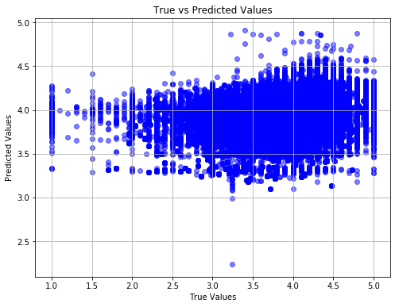

```python
# Scatter plot of true vs predicted values
plt.figure(figsize=(8, 6))
plt.scatter(y_test_2, pred, color='blue', alpha=0.5)
plt.xlabel('True Values')
plt.ylabel('Predicted Values')
plt.title('True vs Predicted Values')
plt.grid(True)
plt.show()
```

```python
from sklearn.metrics import r2_score
r2 = r2_score(y_test_2, pred)
```

```python
r2
```

```
0.13351731851994852
```

```python
# get rmse
from sklearn.metrics import mean_squared_error

mean_squared_error(y_test_2, pred)
```

```
0.1923254083158064
```

```python
import math

rmse = math.sqrt(mean_squared_error(y_test_2, pred))
rmse
```

```
0.438549208545411
```

Let's save our model

```python
from joblib import load,dump
```

```python
# save my model
dump(reg,'SGDRegressor.pkl')
```

```
['SGDRegressor.pkl']
```

```python
# load my model
loaded_model = load('SGDRegressor.pkl')
```

```python
loaded_model
```

```
SGDRegressor(alpha=0.0001, average=False, early_stopping=False, epsilon=0.1,
             eta0=0.01, fit_intercept=True, l1_ratio=0.15,
             learning_rate='invscaling', loss='squared_loss', max_iter=1000,
             n_iter_no_change=5, penalty='l2', power_t=0.25, random_state=42,
             shuffle=True, tol=0.001, validation_fraction=0.1, verbose=0,
             warm_start=False)
```

Time for training on top

```python
loaded_model_trained = loaded_model.partial_fit(X_train,y_train)
```

```python
loaded_model_trained
```

```
SGDRegressor(alpha=0.0001, average=False, early_stopping=False, epsilon=0.1,
             eta0=0.01, fit_intercept=True, l1_ratio=0.15,
             learning_rate='invscaling', loss='squared_loss', max_iter=1000,
             n_iter_no_change=5, penalty='l2', power_t=0.25, random_state=42,
             shuffle=True, tol=0.001, validation_fraction=0.1, verbose=0,
             warm_start=False)
```

```python
# Storing my predictions
loaded_model_pred = loaded_model_trained.predict(X_test_2)
```

```python
from sklearn.metrics import mean_squared_error

mean_squared_error(y_test_2, loaded_model_pred)
```

```
0.19185978902490525
```

```python
import math

rmse_1 = math.sqrt(mean_squared_error(y_test_2, loaded_model_pred))
rmse_1
```

```
0.43801802363019865
```

```python
# check r2 score after 1 run
r2_1 = r2_score(y_test_2, pred)
r2_1
```

```
0.13351731851994852
```

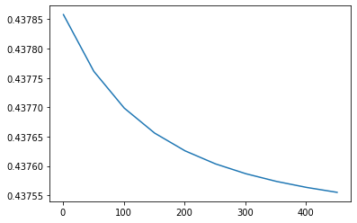

```python
# Training on top, multiple epoch
acc_list = []

for i in range(1,500,50):
    loaded_model_trained = loaded_model.partial_fit(X_train,y_train)
    loaded_model_pred = loaded_model_trained.predict(X_test_2)

    acc_list.append(math.sqrt(mean_squared_error(y_test_2, loaded_model_pred)))

x_range_temp = []
for i in range(1,500,50):
    x_range_temp.append(i)

plt.plot(x_range_temp,acc_list)
```

From the plot we can see as the number of epochs is increasing RMSE value keeps on decreasing.

```python
# load my model
loaded_model = load('SGDRegressor.pkl')
```

```python
# partial fit on new dataset
loaded_model_trained = loaded_model.partial_fit(X_train,y_train)
```

```python
# partial fitting for 400 epochs
for i in range(1,400,50):
    loaded_model_trained = loaded_model.partial_fit(X_train,y_train)
```

```python
# my predictions
loaded_model_pred = loaded_model_trained.predict(X_test_2)
```

```python
rmse_400 = math.sqrt(mean_squared_error(y_test_2, loaded_model_pred))
rmse_400
```

```
0.4375737079287944
```

```python
r2_400 = r2_score(y_test_2, loaded_model_pred)
r2_400
```

```
0.13736780685571737
```

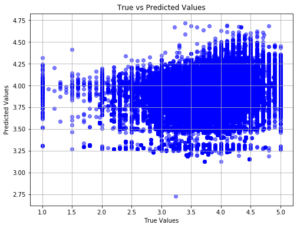

```python
# Scatter plot of true vs predicted values
plt.figure(figsize=(8, 6))
plt.scatter(y_test_2, loaded_model_pred, color='blue', alpha=0.5)
plt.xlabel('True Values')
plt.ylabel('Predicted Values')
plt.title('True vs Predicted Values')
plt.grid(True)
plt.show()
```

PassiveAggressiveRegressor

```python
from sklearn.linear_model import PassiveAggressiveRegressor
```

```python
# Initialising
reg2 = PassiveAggressiveRegressor(random_state = 21)

# Training
reg2.fit(X_train_2, y_train_2)
```

```
PassiveAggressiveRegressor(C=1.0, average=False, early_stopping=False,
                           epsilon=0.1, fit_intercept=True,
                           loss='epsilon_insensitive', max_iter=1000,
                           n_iter_no_change=5, random_state=21, shuffle=True,
                           tol=0.001, validation_fraction=0.1, verbose=0,
                           warm_start=False)
```

```python
# my predictions
pred_reg2 = reg2.predict(X_test_2)
```

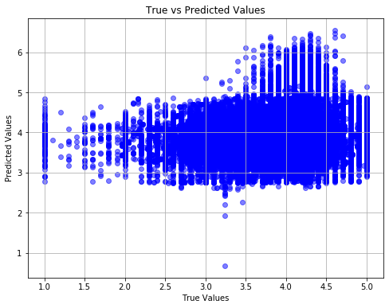

```python
# Scatter plot of true vs predicted values
plt.figure(figsize=(8, 6))
plt.scatter(y_test_2, pred_reg2, color='blue', alpha=0.5)
plt.xlabel('True Values')
plt.ylabel('Predicted Values')
plt.title('True vs Predicted Values')
plt.grid(True)
plt.show()
```

```python
#get rmse
rmse_reg2 = math.sqrt(mean_squared_error(y_test_2, pred_reg2))
rmse_reg2
```

```
0.5806088331721441
```

```python
r2_reg2 = r2_score(y_test_2, pred_reg2)
r2_reg2
```

```
-0.5187647234819865
```

```python
# save my model
dump(reg2,'PassiveAggressiveRegressor.pkl')
```

```
['PassiveAggressiveRegressor.pkl']
```

```python
# load my model
loaded_model = load('PassiveAggressiveRegressor.pkl')
```

```python
loaded_model
```

```
PassiveAggressiveRegressor(C=1.0, average=False, early_stopping=False,
                           epsilon=0.1, fit_intercept=True,
                           loss='epsilon_insensitive', max_iter=1000,
                           n_iter_no_change=5, random_state=21, shuffle=True,
                           tol=0.001, validation_fraction=0.1, verbose=0,
                           warm_start=False)
```

Time for training on top

```python
loaded_model_trained = loaded_model.partial_fit(X_train,y_train)
```

```python
loaded_model_trained
```

```
PassiveAggressiveRegressor(C=1.0, average=False, early_stopping=False,
                           epsilon=0.1, fit_intercept=True,
                           loss='epsilon_insensitive', max_iter=1000,
                           n_iter_no_change=5, random_state=21, shuffle=True,
                           tol=0.001, validation_fraction=0.1, verbose=0,
                           warm_start=False)
```

```python
# Storing my predictions
loaded_model_pred = loaded_model_trained.predict(X_test_2)
```

```python
rmse_reg2_1 = math.sqrt(mean_squared_error(y_test_2, loaded_model_pred))
```

```python
rmse_reg2_1
```

```
0.5948579713016047
```

```python
r2_reg2_1 = r2_score(y_test_2, loaded_model_pred)
r2_reg2_1
```

```
-0.5942256597291775
```

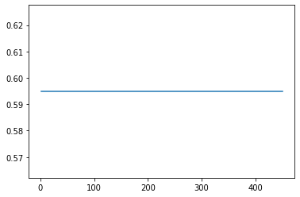

```python
# Training on top, multiple epoch
acc_list = []

for i in range(1,500,50):
    loaded_model_trained = loaded_model.partial_fit(X_train,y_train)
    loaded_model_pred = loaded_model_trained.predict(X_test_2)

    acc_list.append(math.sqrt(mean_squared_error(y_test_2, loaded_model_pred)))

x_range_temp = []
for i in range(1,500,50):
    x_range_temp.append(i)

plt.plot(x_range_temp,acc_list)
```

```python
# load my model
loaded_model = load('PassiveAggressiveRegressor.pkl')
```

```python
# partial fit on new dataset
loaded_model_trained = loaded_model.partial_fit(X_train,y_train)
```

```python
# partial fitting for 400 epochs
for i in range(1,400,50):
    loaded_model_trained = loaded_model.partial_fit(X_train,y_train)
```

```python
# my predictions
loaded_model_pred = loaded_model_trained.predict(X_test_2)
```

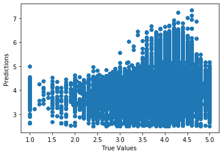

```python
plt.scatter(y_test_2, loaded_model_pred)
plt.xlabel('True Values ')
plt.ylabel('Predictions ')
```

```python
rmse_reg2_400 = math.sqrt(mean_squared_error(y_test_2, loaded_model_pred))
rmse_reg2_400
```

```
0.5948579713016047
```

```python
r2_reg2_400 = r2_score(y_test_2, loaded_model_pred)
r2_reg2_400
```

```
-0.5942256597291775
```

# Model Comparison

For SGDRegressor:

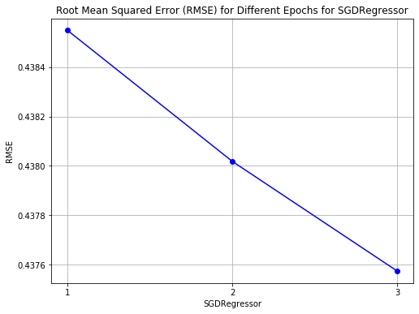

```python
rmse_values = [rmse, rmse_1, rmse_400]

# Plotting RMSE values
plt.figure(figsize=(8, 6))
plt.plot(range(1, len(rmse_values) + 1), rmse_values, marker='o', linestyle='-', color='blue')
plt.xlabel('SGDRegressor')
plt.ylabel('RMSE')
plt.title('Root Mean Squared Error (RMSE) for Different Epochs for SGDRegressor')
plt.xticks(range(1, len(rmse_values) + 1))  # Set x-axis ticks
plt.grid(True)
plt.show()
```

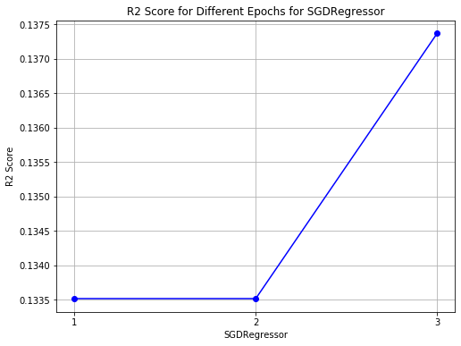

```python
r2_values = [r2, r2_1, r2_400]

# Plotting RMSE values
plt.figure(figsize=(8, 6))
plt.plot(range(1, len(r2_values) + 1), r2_values, marker='o', linestyle='-', color='blue')
plt.xlabel('SGDRegressor')
plt.ylabel('R2 Score')
plt.title('R2 Score for Different Epochs for SGDRegressor')
plt.xticks(range(1, len(r2_values) + 1))  # Set x-axis ticks
plt.grid(True)
plt.show()
```

For PassiveAggressiveRegressor

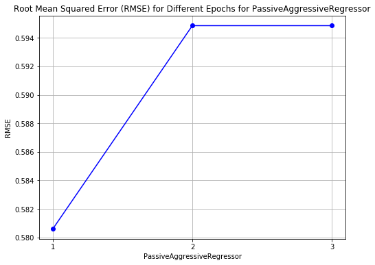

```python
rmse_values = [rmse_reg2, rmse_reg2_1, rmse_reg2_400]

# Plotting RMSE values
plt.figure(figsize=(8, 6))
plt.plot(range(1, len(rmse_values) + 1), rmse_values, marker='o', linestyle='-', color='blue')
plt.xlabel('PassiveAggressiveRegressor')
plt.ylabel('RMSE')
plt.title('Root Mean Squared Error (RMSE) for Different Epochs for PassiveAggressiveRegressor')
plt.xticks(range(1, len(rmse_values) + 1))  # Set x-axis ticks
plt.grid(True)
plt.show()
```

[figure not shown]

```python
r2_values = [r2, r2_reg2_1, r2_reg2_400]

# Plotting RMSE values
plt.figure(figsize=(8, 6))
plt.plot(range(1, len(r2_values) + 1), r2_values, marker='o', linestyle='-', color='blue')
plt.xlabel('PassiveAggressiveRegressor')
plt.ylabel('R2 Score')
plt.title('R2 Score for Different Epochs for PassiveAggressiveRegressor')
plt.xticks(range(1, len(r2_values) + 1))  # Set x-axis ticks
plt.grid(True)
plt.show()
```

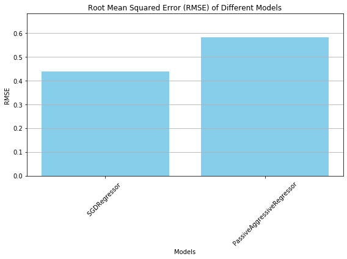

```python
model_names = ['SGDRegressor ', 'PassiveAggressiveRegressor']  # Names of the models
rmse_values = [rmse, rmse_reg2]  # RMSE values for each model

# Plotting RMSE values for different models
plt.figure(figsize=(8, 6))
plt.bar(model_names, rmse_values, color='skyblue')
plt.xlabel('Models')
plt.ylabel('RMSE')
plt.title('Root Mean Squared Error (RMSE) of Different Models')
plt.ylim(0, max(rmse_values) + 0.1)  # Setting y-axis limit slightly higher than the maximum RMSE value
plt.xticks(rotation=45)  # Rotate x-axis labels for better readability if needed
plt.grid(axis='y')  # Show gridlines on the y-axis
plt.tight_layout()  # Adjust layout to prevent clipping of labels
plt.show()
```

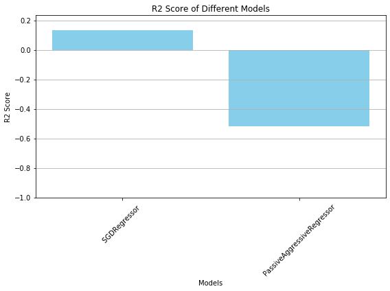

```python
model_names = ['SGDRegressor ', 'PassiveAggressiveRegressor']  # Names of the models
r2_values = [r2, r2_reg2]  # RMSE values for each model

# Plotting RMSE values for different models
plt.figure(figsize=(8, 6))
plt.bar(model_names, r2_values, color='skyblue')
plt.xlabel('Models')
plt.ylabel('R2 Score')
plt.title('R2 Score of Different Models')
plt.ylim(-1, max(r2_values) + 0.1)  # Setting y-axis limit slightly higher than the maximum RMSE value
plt.xticks(rotation=45)  # Rotate x-axis labels for better readability if needed
plt.grid(axis='y')  # Show gridlines on the y-axis
plt.tight_layout()  # Adjust layout to prevent clipping of labels
plt.show()
```

Hence SGDRegressor is good model for our dataset which keeps on getting better after Retraining and increasing number of epochs.